# Code explainer: Changing predictor measurement procedures affected the performance of prediction models in clinical examples

Kim Luijken

This explainer goes over the code used in the manuscript “Changing predictor measurement procedures affected the performance of prediction models in clinical examples” (https://doi.org/10.1016/j.jclinepi.2019.11.001).

## Research setting

The (fictitious) analysis of interest here concerns a prediction model predicting 10-year chronic heart disease based on age, total cholesterol, systematic blood pressure and body mass index (BMI).

#### Predictor measurement heterogeneity

The predictor measurement heterogeneity is defined as follows. The predictor BMI is measured heterogeneously across derivation and validation setting. The preffered measurement BMI is to compute BMI data from participants’ height and weight measurements, obtained by a trained examiner who followed a standardized protocol. The pragmatic measurement of BMI is to compute BMI data via self-reported weight and height by the participants.

## Load the data

Since the empirical data presented in the manuscript is not publicly available, we simulated a dataset that can be used to run the code.  
The file `./data/raw_data/simulated_data.rds` can be used to simulate data, resulting in a file with $3,000$ observations and $6$ variables.

| age | totChol | sysBP | BMI | BMIself | TenYearCHD |
| --- | --- | --- | --- | --- | --- |
| 67.8 | 269.7 | 137.6 | 25.3 | 23.3 | 1 |
| 57.8 | 313.6 | 171.1 | 33.4 | 28.8 | 0 |
| 52.9 | 218.7 | 86.3 | 27.5 | 24.5 | 0 |
| 57.9 | 147.1 | 144.1 | 26.8 | 24.4 | 0 |
| 61.6 | 231.4 | 145.5 | 20.5 | 19.5 | 0 |
| 47.2 | 170.6 | 109.2 | 24.3 | 23.1 | 0 |

## Standardize the data

The function `./rcode/analysis/standardize_data.R` standardizes the names of the dataset for further analysis. In what follows, we denote the preferred measurement of BMI by $X$ and the pragmatic measurement of BMI by $W$.

```r
data <- standardize_data(inputdata = original_data,
                         nameY = "TenYearCHD",
                         nameX = "BMI",
                         nameW = "BMIself",
                         numberZ = 3,
                         namesZ=c("age","totChol","sysBP"))
```

| Y | X | W | Z1 | Z2 | Z3 |
| --- | --- | --- | --- | --- | --- |
| 1 | 25.3 | 23.3 | 67.8 | 269.7 | 137.6 |
| 0 | 33.4 | 28.8 | 57.8 | 313.6 | 171.1 |
| 0 | 27.5 | 24.5 | 52.9 | 218.7 | 86.3 |
| 0 | 26.8 | 24.4 | 57.9 | 147.1 | 144.1 |
| 0 | 20.5 | 19.5 | 61.6 | 231.4 | 145.5 |
| 0 | 24.3 | 23.1 | 47.2 | 170.6 | 109.2 |

## Generate descriptives

We first describe each variable in the dataset to get insight into the data structure. Descriptives of each variable (mean/sd/minimum/median/maximum/missing values) are saved as a table in an .html file, in the style of the `dfSummary` function in the summarytools package. Furthermore, the partial correlation is saved as a measure of similarity in measurements $X$ and $W$. All functionalities are described in `./rcode/analysis/descriptives.R`

Data Frame Summary

data

**Dimensions**: 3000 x 6  
**Duplicates**: 0

| **No** | **Variable** | **Label** | **Stats / Values** | **Freqs (% of Valid)** | **Graph** | **Valid** | **Missing** |
| --- | --- | --- | --- | --- | --- | --- | --- |
| 1 | Y [labelled, integer] | TenYearCHD | Min : 0 Mean : 0.2 Max : 1 | 0 : 2418 ( 80.6% ) 1 : 582 ( 19.4% ) |  | 3000 (100%) | 0 (0%) |
| 2 | X [labelled, numeric] | BMI | Mean (sd) : 26 (4.2) min < med < max: 12.1 < 26 < 41.5 IQR (CV) : 5.7 (0.2) | 3000 distinct values |  | 3000 (100%) | 0 (0%) |
| 3 | W [labelled, numeric] | BMIself | Mean (sd) : 24 (4.1) min < med < max: 10.2 < 24 < 37.5 IQR (CV) : 5.4 (0.2) | 3000 distinct values |  | 3000 (100%) | 0 (0%) |
| 4 | Z1 [labelled, numeric] | age | Mean (sd) : 60.1 (8.7) min < med < max: 27.1 < 60.3 < 86.5 IQR (CV) : 12 (0.1) | 3000 distinct values |  | 3000 (100%) | 0 (0%) |
| 5 | Z2 [labelled, numeric] | totChol | Mean (sd) : 240.1 (44.3) min < med < max: 89.7 < 240.7 < 401.5 IQR (CV) : 60.6 (0.2) | 3000 distinct values |  | 3000 (100%) | 0 (0%) |
| 6 | Z3 [labelled, numeric] | sysBP | Mean (sd) : 130.3 (22.2) min < med < max: 52.3 < 130.4 < 205.3 IQR (CV) : 30.1 (0.2) | 3000 distinct values |  | 3000 (100%) | 0 (0%) |

Generated by summarytools 0.9.6 ([R](https://www.r-project.org/) version 3.6.3)  
2020-07-16

## Analyse the data

> *NOTE:* Make sure the files under `./data/analysis` are empty. The analysis functions append output of each bootstrap run to the existing .rds file, meaning that if files are already saved in this folder, the output will be combined.

A description of the methods can be found in the main manuscript. Briefly, we assessed the optimism-corrected predictive performance of a regular maximum likelihood logistic regression model under both predictor measurement homogeneity and heterogeneity. Measures of predictive performance were obtained by deriving and validating a prediction model in 500 bootstrap samples and averaging optimism-corrected measures of performance over the bootstrap samples. We estimated the calibration-in-the-large coefficient and calibration slope from a logistic regression recalibration model, the c-statistic, the Brier Score, the scaled Brier score and Nagelkerke’s R squared. All estimation procedures can be found in `./rcode/analysis/helpers/performance_measures.R`. The predictive performance evaluation was based on the `val.prob()` function in the rms package.

#### Apparent performance

The apparent performance of the prediction model was estimated in the full dataset, see `./rcode/analysis/helpers/workflow_apparent_performance.R`.

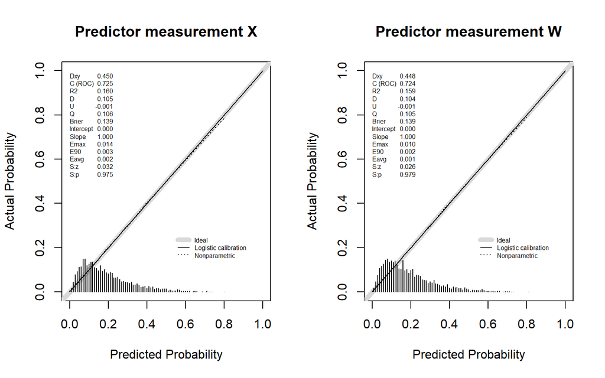

#### Internal performance under measurement homogeneity

To assess predictor measurement homogeneity, the prediction model was derived and validated based on the same predictor definitions, see `./rcode/analysis/helpers/workflow_internal_performance.R`.

| Event fraction | Measurement strategy | Mean value measurement | Standard deviation measurement | C-statistic | Scaled Brier score |
| --- | --- | --- | --- | --- | --- |
| 0.194 | BMI (preferred) | 25.98 | 4.22 | 0.72 (95% CI,0.7; 0.75) | 0.44 (95% CI,0.4; 0.47) |
| 0.194 | BMIself (pragmatic) | 23.97 | 4.10 | 0.72 (95% CI,0.7; 0.75) | 0.44 (95% CI,0.4; 0.47) |

#### Internal performance under measurement heterogeneity

To assess predictor measurement homogeneity, the prediction model was derived and validated based on the same predictor definitions. To assess predictor measurement heterogeneity, a derivation and validation setting were recreated by deriving the model using the preferred measurement and validating the model using the pragmatic measurement, or by deriving the model using the pragmatic measurement and validating the model using the preferred measurement, see `./rcode/analysis/helpers/workflow_internal_performance.R`.

| Measurement strategy at derivation | Measurement strategy at validation | Partial correlation | Calibration in the large | Calibration slope | Delta C-statistic | Delta scaled Brier score |
| --- | --- | --- | --- | --- | --- | --- |
| BMI | BMIself | 0.91 | 0.046 (95% CI,-0.004; 0.101) | 1 (95% CI,0.993; 1.007) | -0.001 (95% CI,-0.003; 0) | 0 (95% CI,-0.001; 0) |
| BMIself | BMI | 0.91 | -0.034 (95% CI,-0.092; 0.019) | 1 (95% CI,0.993; 1.004) | 0.001 (95% CI,-0.001; 0.002) | 0 (95% CI,-0.001; 0) |

## Generate visuals

The predictive performance measures estimated in each of the bootstrap samples were plotted. We present an example of the calibration-in-the-large coefficient here.

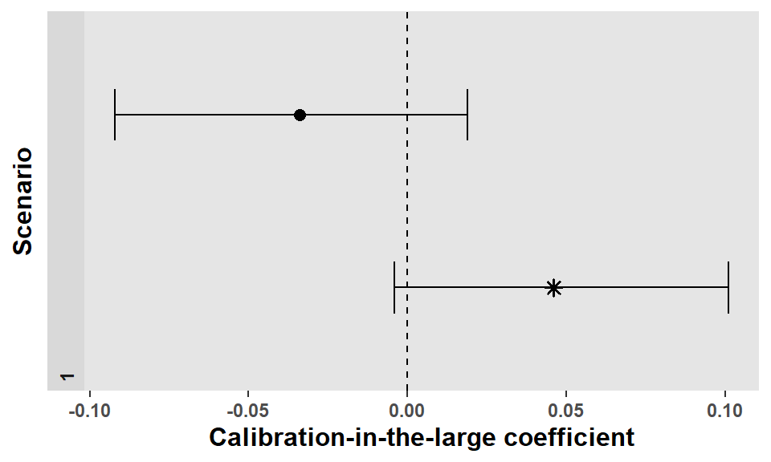

Furthermore, smooth calibration slopes were plotted and shown in supplementary file 2. We show an example for Maximum likelihood fit under predictor measurement heterogeneity (derivation measurement = $X$, validation measurement = $W$) below.

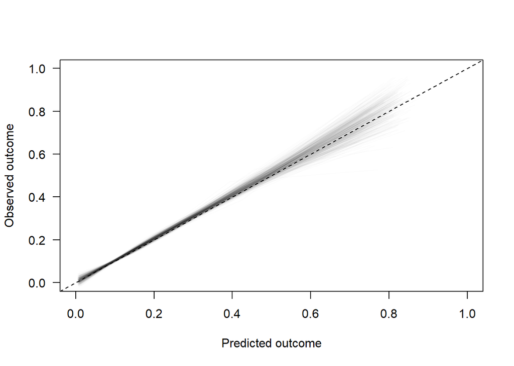